# College Dataset

### Model:XGBoost Regression

```r
x <- model.matrix(Apps ~ ., data = train)[, -1] #remove intercept
y <- train$Apps

set.seed(123)
xgb_1 <- xgboost(data = x,
                 label = y,
                 eta = 0.1,                       #learning rate
                 lambda = 0,                      #regularization term
                 max_depth = 8,                   #tree depth
                 nround = 1000,                   #max number of boosting iterations
                 subsample = 0.65,                #percent of training data to sample for each tree
                 objective = "reg:squarederror",  #for regression models
                 verbose = 0                      #silent
)
```

```r
#train RMSE
xgb_1$evaluation_log
```

```
##       iter train_rmse
##    1:    1   0.937214
##    2:    2   0.848563
##    3:    3   0.767884
##    4:    4   0.692552
##    5:    5   0.624395
##   ---
##  996:  996   0.000404
##  997:  997   0.000404
##  998:  998   0.000404
##  999:  999   0.000404
## 1000: 1000   0.000404
```

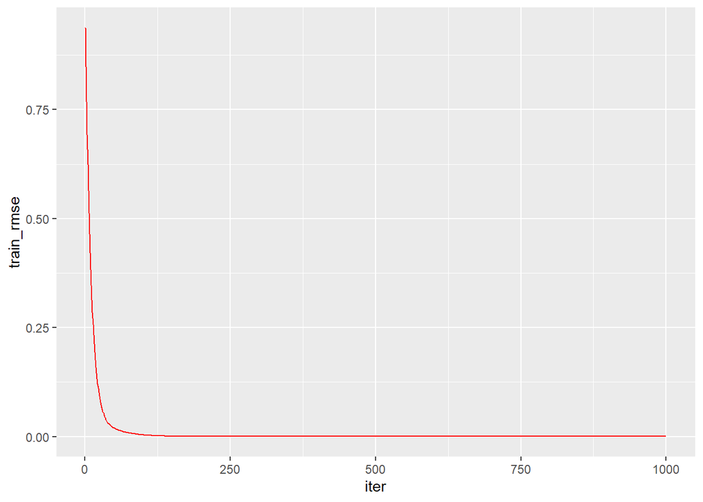

```r
#plot error vs number trees
library(ggplot2)
ggplot(xgb_1$evaluation_log) +
  geom_line(aes(iter, train_rmse), color = "red")
```

```r
#Tuning(Train/validation using xgboost)
#Train and validation sets
set.seed(123)
train_cases_2 <- sample(1:nrow(train), nrow(train) * 0.8)
#Train data set
train_xgboost <- train[train_cases_2,]
dim(train_xgboost)
```

```
## [1] 433  18
```

```r
#Model Matrix
xtrain <- model.matrix(Apps ~  ., data = train_xgboost)[, -1] #remove intercept
ytrain <- train_xgboost$Apps
#Validation data set
validation_xgboost  <- train[-train_cases_2,]
dim(validation_xgboost)
```

```
## [1] 109  18
```

```r
xvalidation <- model.matrix(Apps ~ . , data = validation_xgboost)[, -1] #remove intercept
yvalidation <- validation_xgboost$Apps

#Create hyper-parameter grid
par_grid <- expand.grid(eta = c(0.01, 0.05, 0.1, 0.3),
                        lambda = c(0, 50, 100, 1000),
                        max_depth = c(2, 3, 4, 5),
                        subsample = c(0.65, 0.8, 1),
                        colsample_bytree = c(0.5, 0.8, 0.9, 1))

dim(par_grid)
```

```
## [1] 768   5
```

```r
#Grid search
for(i in 1:nrow(par_grid )) {
  set.seed(123)

  #train model
  xgb_tune <- xgboost(data =  xtrain,
                      label = ytrain,
                      eta = par_grid$eta[i],
                      max_depth = par_grid$max_depth[i],
                      subsample = par_grid$subsample[i],
                      colsample_bytree = par_grid$colsample_bytree[i],
                      nrounds = 1000,
                      objective = "reg:squarederror",  #for regression models
                      verbose = 0,                     #silent,
                      early_stopping_rounds = 10       #stop if no improvement for 10 consecutive trees
  )

  #prediction on validation data set
  pred_xgb_validation <- predict(xgb_tune, xvalidation)
  rmse <- sqrt(mean((yvalidation - pred_xgb_validation) ^ 2))

  #add validation error
  par_grid$RMSE[i]  <- rmse
}

head(par_grid)
```

```
##    eta lambda max_depth subsample colsample_bytree      RMSE
## 1 0.01      0         2      0.65              0.5 0.2409163
## 2 0.05      0         2      0.65              0.5 0.2358567
## 3 0.10      0         2      0.65              0.5 0.2236895
## 4 0.30      0         2      0.65              0.5 0.2669570
## 5 0.01     50         2      0.65              0.5 0.2409163
## 6 0.05     50         2      0.65              0.5 0.2358567
```

```r
#Final Model
set.seed(123)
xgb_2 <- xgboost(data = x,
                 label = y,
                 eta = 0.5,     #learning rate
                 max_depth = 3,  #tree depth
                 lambda = 0,
                 nround = 1000,
                 colsample_bytree = 1,
                 subsample = 0.8,                 #percent of training data to sample for each tree
                 objective = "reg:squarederror",  #for regression models
                 verbose = 0                      #silent
)

#Test the Model----------------------------------
#Model: xgb_2
x_test <- model.matrix(Apps ~ . , data = test)[, -1]#remove intercept
pred_xgb <- predict(xgb_2, x_test)
```

```r
#Absolute error mean, median, sd, max, min-------
abs_err_xgb <- abs(pred_xgb - test$Apps)
MSE_xgb<-mean((test$Apps-pred_xgb)^2)
rmse_xgb<-sqrt(mean((test$Apps-pred_xgb)^2))
```

MSE_xgb = 0.0453192.

RMSE_xgb = 0.212883.

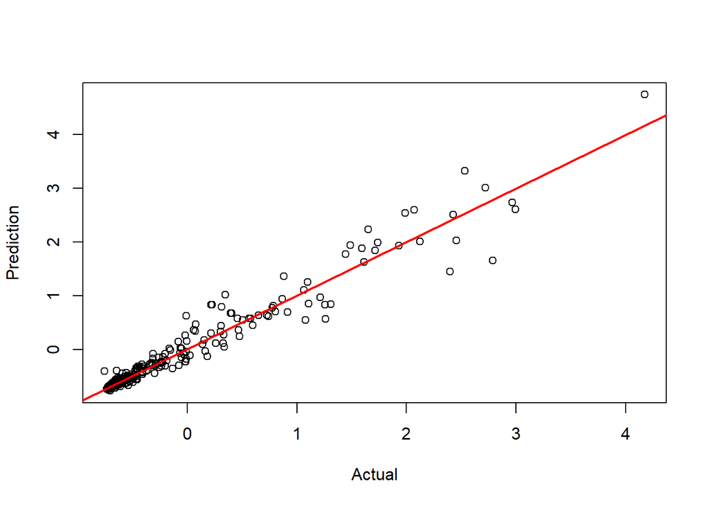

```r
#Actual vs. Predicted
plot(test$Apps, pred_xgb, xlab = "Actual", ylab = "Prediction")
abline(a = 0, b = 1, col = "red", lwd = 2)
```

# Results

## Errors comparison and Model Selection

```r
#Comparisons of Models--------------------------
df <- data.frame("Model_1"  = abs_err_lm_1,
                 "model_2"  = abs_err_lm_2,
                 "Model_3"  = abs_err_bestsub,
                 "model_4"  = abs_err_bestsub_fwd,
                 "model_5"  = abs_err_bestsub_cv,
                 "model_6"  = abs_err_trimmed_bestsub,
                 "model_7"  = abs_err_ridgereg,
                 "Model_8"  = abs_err_lassoreg,
                 "model_9"  = abs_err_tree,
                 "model_10" = abs_err_bagging,
                 "model_11" = abs_err_rf,
                 "model_12" = abs_err_gbm,
                 "model_13" = abs_err_xgb)

models_comp <- data.frame("MSE" = apply(df,2, function(x) mean(x^2)),
                          "RMSE" = apply(df,2,function(x) sqrt(mean(x^2))),
                          "Mean of AbsErrors"   = apply(df, 2, mean),
                          "Median of AbsErrors" = apply(df, 2, median),
                          "SD of AbsErrors"  = apply(df, 2, sd),
                          "IQR of AbsErrors" = apply(df, 2, IQR),
                          "Min of AbsErrors" = apply(df, 2, min),
                          "Max of AbsErrors" = apply(df, 2, max))

rownames(models_comp)[1:13] <- c("LM","LM-t_test","BestSub","Bestsub_fwd_bwd", " Bestsub_CV",
                                "Trimmed_Bestsub","RidgeReg","LassoReg","Tree","Bagging",
                                "Random_Forrest", "GB_Reg", "XGBReg")

models_comp<-models_comp[order(models_comp$RMSE),]
models_comp
```

```
##                        MSE      RMSE Mean.of.AbsErrors Median.of.AbsErrors
## Random_Forrest  0.03720599 0.1928885         0.1068812          0.04813195
## GB_Reg          0.03771095 0.1941931         0.1159583          0.06119493
## XGBReg          0.04531918 0.2128830         0.1225546          0.05448475
## Bagging         0.04758158 0.2181320         0.1142374          0.04062904
## LM-t_test       0.05279581 0.2297734         0.1489490          0.09244858
## BestSub         0.05373187 0.2318014         0.1529035          0.10013040
## Bestsub_fwd_bwd 0.05373187 0.2318014         0.1529035          0.10013040
##  Bestsub_CV     0.05376910 0.2318816         0.1531217          0.09974443
## LM              0.05377853 0.2319020         0.1531012          0.09948975
## LassoReg        0.05394706 0.2322651         0.1428150          0.08661914
## RidgeReg        0.05450036 0.2334531         0.1543256          0.09784258
## Tree            0.05690491 0.2385475         0.1231208          0.04081599
## Trimmed_Bestsub 0.07143217 0.2672680         0.1299242          0.06121501
##                 SD.of.AbsErrors IQR.of.AbsErrors Min.of.AbsErrors
## Random_Forrest        0.1609146        0.1149689     2.645556e-04
## GB_Reg                0.1561065        0.1070358     1.335903e-04
## XGBReg                0.1744424        0.1163067     4.596887e-05
## Bagging               0.1862263        0.1025615     5.395068e-05
## LM-t_test             0.1753338        0.1385422     1.288448e-03
## BestSub               0.1745945        0.1409790     1.942733e-04
## Bestsub_fwd_bwd       0.1745945        0.1409790     1.942733e-04
##  Bestsub_CV           0.1745094        0.1425647     4.380822e-04
## LM                    0.1745546        0.1426557     2.301713e-04
## LassoReg              0.1835634        0.1321281     2.958672e-04
## RidgeReg              0.1755455        0.1409299     1.509203e-03
## Tree                  0.2047587        0.1168290     5.646179e-04
## Trimmed_Bestsub       0.2340663        0.1070688     6.754955e-05
##                 Max.of.AbsErrors
## Random_Forrest         1.0105889
## GB_Reg                 0.9550947
## XGBReg                 1.1280471
## Bagging                1.1818049
## LM-t_test              1.3601290
## BestSub                1.3742120
## Bestsub_fwd_bwd        1.3742120
##  Bestsub_CV            1.3721573
## LM                     1.3721243
## LassoReg               1.4823091
## RidgeReg               1.3840797
## Tree                   1.2961140
## Trimmed_Bestsub        1.9178733
```

Finally, in order to comparison and evaluate the performance of models, several parameters were calculated and listed. It should be noted that 13 models were built as follows:

Model 1: Linear Regression

Model 2: Linear Regression with variable selection based on t-test results in model 1

Model 3: Linear Regression + Stepwise (method = “exhaustive”)

Model 4: Linear Regression with forward and backward stepwise

Model 5: Linear Regression + stepwise + K-fold cross validation

Model 6: Linear Regression after removing outliers with tukey method

Model 7: Ridge Regression

Model 8: Lasso Regression

Model 9: Decision Tree

Model 10: Bagging

Model 11: Random Forest

Model 12: Gradient Boost Regression

Model 13: XG Boost Regression

In Final table, Mean, Median, SD, IQR, Min, Max, MSE and RMSE of errors have been reported.

Based On both MSE and RMSE, Random_Forest, Gradient boost regression and XG Boost Regression have shown the best performance (Lower Error) with descending order.

**Conclusion:**

The achievements of this project for me is as follow:

- I learn how to implement different ML algorithms and methods.
- My R programming language has been strengthen.
- Behind the scene, I Study statistics deeply for better comprehension and interpretation of the models’ results.
- I found how can I find algorithms and the way of implementation on online communities.
- I can have close collaboration with my classmates and help them in their problems with doing their projects.

**Challenges**

- My first Challenge was that there was little information about the Dataset. I could not find further information to help me in providing better response to the requested answers. Eventually, I tried to comprehend the project with similar projects and situation.
- The second challenge that I had faced with was normalizing the data. Normalization increased the errors. however, I understood that standardization improve the performance of my models, since the values of variables are not in the same order.